# FIT5149 Assignment1

Sudent Name : Md Khaled Iqbal  
Student ID: 31932576

# Introduction

We have been provided with the insurance data set to predict whether a customer will churn or not. I will perform an exploratory data analysis to dig deeper into the data set.The strategy will be, as the data set is said to be clean ,I will not waste much time in data wrangling part. I will investigate the data set for its each features and their individual distributions. After that i will try to perform a Bi-variate analysis and see how they are correlated with respect to other features and target variable. Then i will perform a feature selection process to select the most significant features in terms of their explainability of target variable. I will check the distribution of the target variable and if they are imbalanced , try different techniques to mitigate the imbalance problem in-order to get a reliable performance from the developed models. I will select two models and analyse the performance based on different performance parameters with some hyper parameter tuning. Finally, i will produce some marketing suggestion based on the knowledge i gained from the EDA and model performances.

# EDA(Exploratory Data Analysis)

### Loading the Data

```r
df_train <- read.csv("trainSet.csv")
df_test <- read.csv("testSet.csv")
```

### Training data set

```
##    feature_0  feature_1  feature_2  feature_3   feature_4  feature_5  feature_6
## 1  1.5127910 -0.2434605  0.1434182  2.0185885  0.07622994 -0.4114531 -0.2519404
## 2 -1.5007763 -0.2125875  1.2248391 -0.1598411 -0.56935064 -0.4114531 -0.2519404
## 3  0.9477471  0.5812426 -0.3372133  0.7798736 -0.56935064 -0.4114531 -0.2519404
## 4 -0.8415585 -0.2217837  0.5038918 -0.3772958  0.39902023 -0.4114531 -0.2519404
## 5 -0.5590365 -0.5922597 -1.1783185 -0.4161270 -0.56935064 -0.4114531 -0.2519404
##   feature_7 feature_8 feature_9 feature_10 feature_11 feature_12 feature_13
## 1         1         1         1          0          1          0          0
## 2         8         2         1          0          0          0          0
## 3         0         2         1          0          0          0          2
## 4         9         1         1          0          0          0          0
## 5         1         2         1          0          1          0          0
##   feature_14 feature_15 labels
## 1          0          3      0
## 2          8          3      0
## 3          8          3      0
## 4          1          3      0
## 5          8          3      0
```

### Test data set

```
##    feature_0  feature_1  feature_2  feature_3   feature_4  feature_5  feature_6
## 1 -1.0299064 -0.2224406  0.5038918 -0.9053999  0.07622994 -0.4114531 -0.2519404
## 2 -0.8415585 -0.3564425 -1.5387921 -0.1054775  2.98134255 -0.4114531 -0.2519404
## 3 -1.5007763 -0.2648089 -1.4186342  0.3993280 -0.56935064 -0.4114531 -0.2519404
## 4 -0.2765146 -0.4024236  1.8256285 -0.8976337  6.20924545 -0.4114531 -0.2519404
## 5 -0.9357324 -0.2677648  1.5853127  0.0537304 -0.56935064 -0.4114531 -0.2519404
##   feature_7 feature_8 feature_9 feature_10 feature_11 feature_12 feature_13
## 1         0         1         1          0          1          0          2
## 2         0         1         1          0          1          0          2
## 3         7         2         1          0          1          1          2
## 4         0         1         1          0          1          0          0
## 5         0         2         1          0          1          0          0
##   feature_14 feature_15 labels
## 1          6          3      0
## 2          6          3      0
## 3          6          3      0
## 4          5          3      0
## 5          4          3      0
```

### Data Structure of the Data Set

```
## 'data.frame':    27126 obs. of  17 variables:
##  $ feature_0 : num  1.513 -1.501 0.948 -0.842 -0.559 ...
##  $ feature_1 : num  -0.243 -0.213 0.581 -0.222 -0.592 ...
##  $ feature_2 : num  0.143 1.225 -0.337 0.504 -1.178 ...
##  $ feature_3 : num  2.019 -0.16 0.78 -0.377 -0.416 ...
##  $ feature_4 : num  0.0762 -0.5694 -0.5694 0.399 -0.5694 ...
##  $ feature_5 : num  -0.411 -0.411 -0.411 -0.411 -0.411 ...
##  $ feature_6 : num  -0.252 -0.252 -0.252 -0.252 -0.252 ...
##  $ feature_7 : int  1 8 0 9 1 4 7 6 6 9 ...
##  $ feature_8 : int  1 2 2 1 2 2 1 1 1 1 ...
##  $ feature_9 : int  1 1 1 1 1 2 1 2 1 3 ...
##  $ feature_10: int  0 0 0 0 0 1 0 0 0 0 ...
##  $ feature_11: int  1 0 0 0 1 1 0 1 1 1 ...
##  $ feature_12: int  0 0 0 0 0 0 0 1 1 0 ...
##  $ feature_13: int  0 0 2 0 0 0 0 2 0 0 ...
##  $ feature_14: int  0 8 8 1 8 8 1 6 5 9 ...
##  $ feature_15: int  3 3 3 3 3 0 3 3 3 3 ...
##  $ labels    : int  0 0 0 0 0 0 0 0 0 0 ...
```

##### Comments:

We can see that our training data set has total 27126 observations and 17 features.out of 17 features there are 7 features which are numeric and remaining are categorical.Among the features, 16 are predictor variables and the feature “labels” is our target variable.

### Summary of Training Data set

```
##    feature_0           feature_1           feature_2
##  Min.   :-2.159994   Min.   :-3.081149   Min.   :-1.779108
##  1st Qu.:-0.747384   1st Qu.:-0.422458   1st Qu.:-0.938003
##  Median :-0.182341   Median :-0.296996   Median : 0.023260
##  Mean   :-0.004908   Mean   : 0.001337   Mean   : 0.003681
##  3rd Qu.: 0.665225   3rd Qu.: 0.023886   3rd Qu.: 0.624050
##  Max.   : 5.091402   Max.   :26.222907   Max.   : 1.825629
##    feature_3           feature_4           feature_5
##  Min.   :-1.002478   Min.   :-0.569351   Min.   :-0.411453
##  1st Qu.:-0.602517   1st Qu.:-0.569351   1st Qu.:-0.411453
##  Median :-0.307400   Median :-0.246560   Median :-0.411453
##  Mean   :-0.002433   Mean   :-0.000047   Mean   :-0.002946
##  3rd Qu.: 0.232354   3rd Qu.: 0.076230   3rd Qu.:-0.411453
##  Max.   :18.094700   Max.   :19.443647   Max.   : 8.127648
##    feature_6           feature_7        feature_8      feature_9
##  Min.   :-0.251940   Min.   : 0.000   Min.   :0.00   Min.   :0.000
##  1st Qu.:-0.251940   1st Qu.: 1.000   1st Qu.:1.00   1st Qu.:1.000
##  Median :-0.251940   Median : 4.000   Median :1.00   Median :1.000
##  Mean   :-0.009104   Mean   : 4.336   Mean   :1.17   Mean   :1.226
##  3rd Qu.:-0.251940   3rd Qu.: 7.000   3rd Qu.:2.00   3rd Qu.:2.000
##  Max.   :23.625644   Max.   :11.000   Max.   :2.00   Max.   :3.000
##    feature_10        feature_11       feature_12      feature_13
##  Min.   :0.00000   Min.   :0.0000   Min.   :0.000   Min.   :0.0000
##  1st Qu.:0.00000   1st Qu.:0.0000   1st Qu.:0.000   1st Qu.:0.0000
##  Median :0.00000   Median :1.0000   Median :0.000   Median :0.0000
##  Mean   :0.01788   Mean   :0.5522   Mean   :0.159   Mean   :0.6365
##  3rd Qu.:0.00000   3rd Qu.:1.0000   3rd Qu.:0.000   3rd Qu.:2.0000
##  Max.   :1.00000   Max.   :1.0000   Max.   :1.000   Max.   :2.0000
##    feature_14       feature_15        labels
##  Min.   : 0.000   Min.   :0.000   Min.   :0.0000
##  1st Qu.: 3.000   1st Qu.:3.000   1st Qu.:0.0000
##  Median : 6.000   Median :3.000   Median :0.0000
##  Mean   : 5.513   Mean   :2.562   Mean   :0.1173
##  3rd Qu.: 8.000   3rd Qu.:3.000   3rd Qu.:0.0000
##  Max.   :11.000   Max.   :3.000   Max.   :1.0000
```

##### Comments:

We can see the distribution of the data set.Each feature has its own distribution with inter-quartile distances, min, max ,mean,median etc.

### Missing Values

```r
missing_val <- sum(is.na(df_train))
missing_val
```

```
## [1] 0
```

##### Comments:

We can see that our training data set has 0 missing values.

##### Comments:

Now we will get the list of columns/features as a list so that we can utilize them in future

```r
features <- names(df_train)
features
```

```
##  [1] "feature_0"  "feature_1"  "feature_2"  "feature_3"  "feature_4"
##  [6] "feature_5"  "feature_6"  "feature_7"  "feature_8"  "feature_9"
## [11] "feature_10" "feature_11" "feature_12" "feature_13" "feature_14"
## [16] "feature_15" "labels"
```

```r
df_train$labels <- as.factor(df_train$labels) ## Changing our target variable to factors
```

# Univariate Analysis

##### Comments:

We will try to see the distribution of all the variables at a glance before analysing them individually

```
## Error : The fig.showtext code chunk option must be TRUE
```

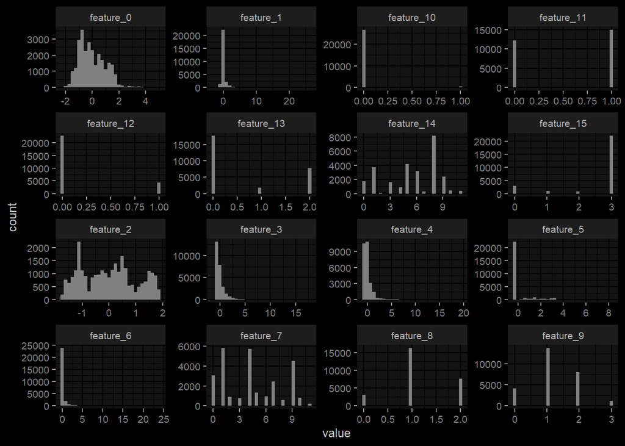

```r
df_train %>%
  keep(is.numeric) %>%
  gather() %>%
  ggplot(aes(value)) +
    facet_wrap(~ key, scales = "free") +
    geom_histogram()
```

##### Function to generate plots for individual features

```r
## In this function we will pass the individual feature name as argument and the function will produce a histogram and a density plot to see the distribution of each feature with respect to target variable

generate_plot1 <- function (x){
  names=names(df_train)
   a=(names[x])
      plot1 <-  ggplot(data=df_train,aes_string(x=a),environment = environment())

## This will generate the density plot of the feature for different target levels
plot2 <-
  plot1+
  geom_density(aes(fill = labels), alpha = 0.4) +
  scale_color_manual(values = c("red", "yellow"))

## This will generate the histogram of the feature for different target levels
plot3 <- plot1+geom_histogram(aes(y=..density..,color = labels,fill = labels),
                   position = "identity",alpha=0.2) +
  scale_color_manual(values = c("red", "blue"))

## This will arrange the two plots in one window
ggarrange(plot2,plot3,ncol = 1,nrow = 2)



}
```

```r
## In this function we will pass the individual feature name as argument and the function will produce a box plot to see the distribution of that feature and the presence of any outliers.

generate_plot2 <- function (x){
  names=names(df_train)
   a=(names[x])
   plot1 <-  ggplot(data=df_train,aes_string(x=a),environment = environment())

  ## Here we will generate the Box plot for that particular feature
   plot4 <- plot1+
  geom_boxplot(outlier.colour = 'red',outlier.size = 2,outlier.alpha = 0.2,outlier.shape = 1)
plot4
}
```

##### Comments:

Now we have to just call the functions defined above and pass the feature name to generate the respective distributions for that particular feature.

### Distribution of Each Feature

### Feature_0

```
## Error : The fig.showtext code chunk option must be TRUE
```

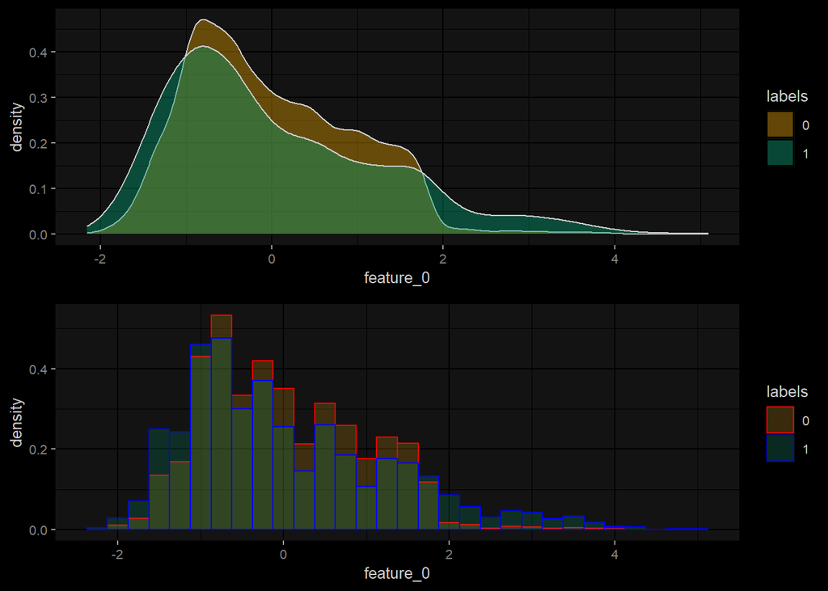

##### Comments:

We can see that the distribution of the feature for different target levels is almost same.It is evident in the density plots.The two different levels are following each other.As the values are distributed over the range, this feature can be interesting and we need to keep an eye on it in future analysis.

```
## Error : The fig.showtext code chunk option must be TRUE
```

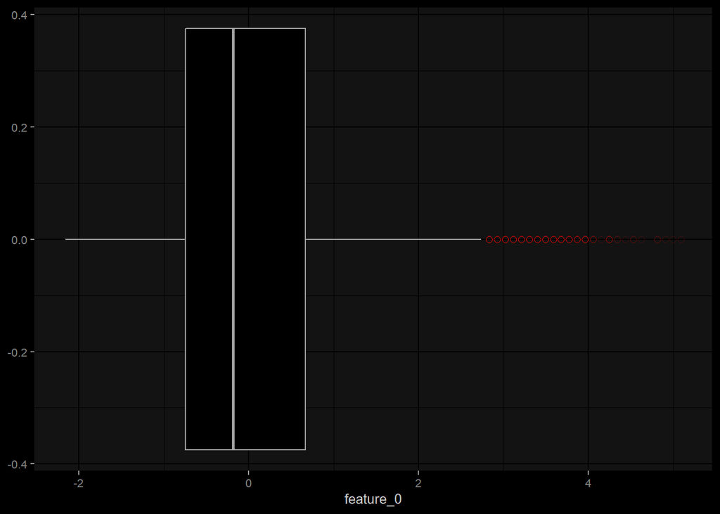

##### Comments:

We can see the feature has some outliers.We need to decide how to deal with the outliers later.

### Feature_1

```
## Error : The fig.showtext code chunk option must be TRUE
```

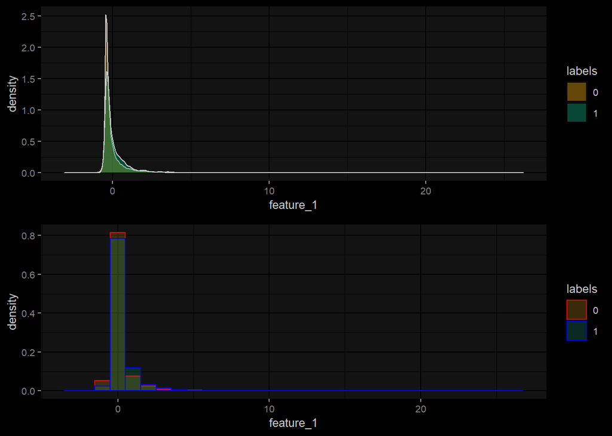

##### Comments:

We can see that the distribution of the feature for different target levels is also almost same.It is evident in the density plots.The two different levels are following each other.As the values are distributed in a concentrated range, this feature can be a weak predictor of the target variables.We need to verify this assumption during our statistical analysis.

```
## Error : The fig.showtext code chunk option must be TRUE
```

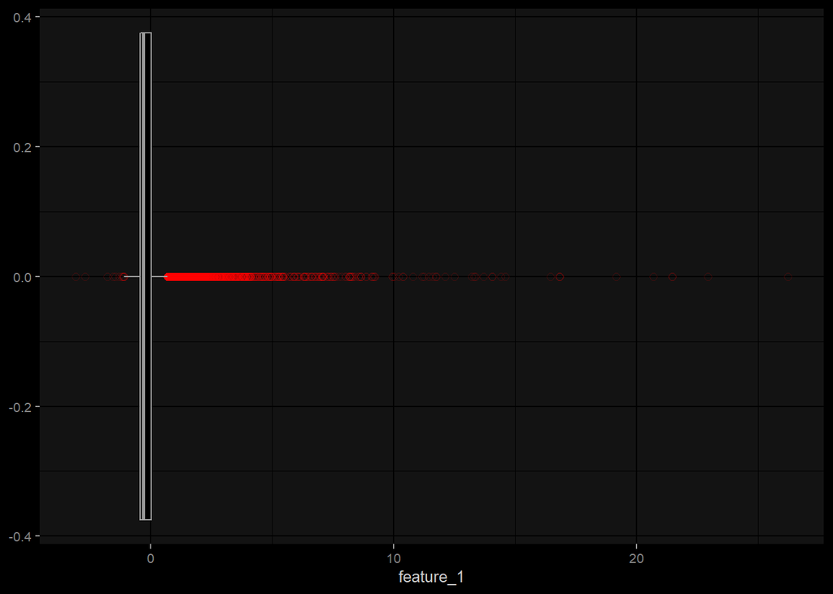

##### Comments:

We can see the feature has lots of outliers.If we get rid of the outliers the distribution of the variable will concentrate more to certain area which means the variable will loose variability in explaining the target variable. We will decide later what to do with these outliers.It already seems a week predictor.We need to check during statistical analysis.

### Feature_2

```
## Error : The fig.showtext code chunk option must be TRUE
```

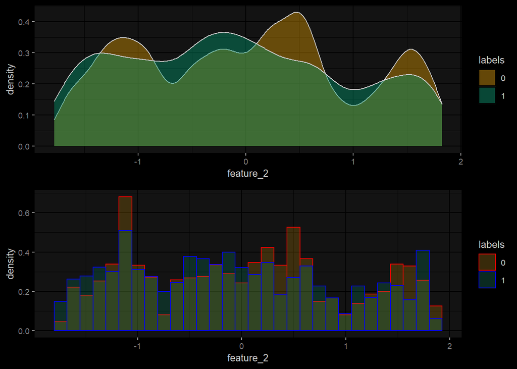

##### Comments:

We can see that the distribution of the feature for different target levels is also almost same.It is evident in the density plots.The two different levels are following each other.As the values are distributed over the range, this feature can be interesting as well and we need to keep an eye on it in future analysis.

```
## Error : The fig.showtext code chunk option must be TRUE
```

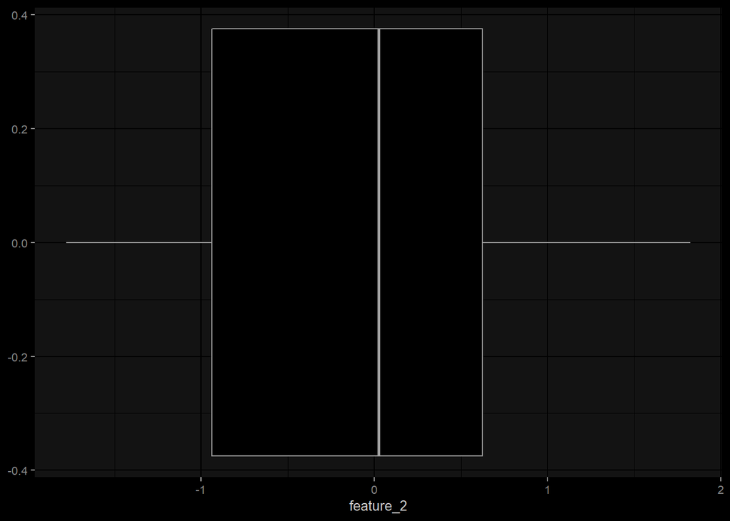

##### Comments:

Interestingly this feature has almost no outlier.The values are distributed over the range well.We need further analysis to take any decision about this feature.

### Feature_3

```
## Error : The fig.showtext code chunk option must be TRUE
```

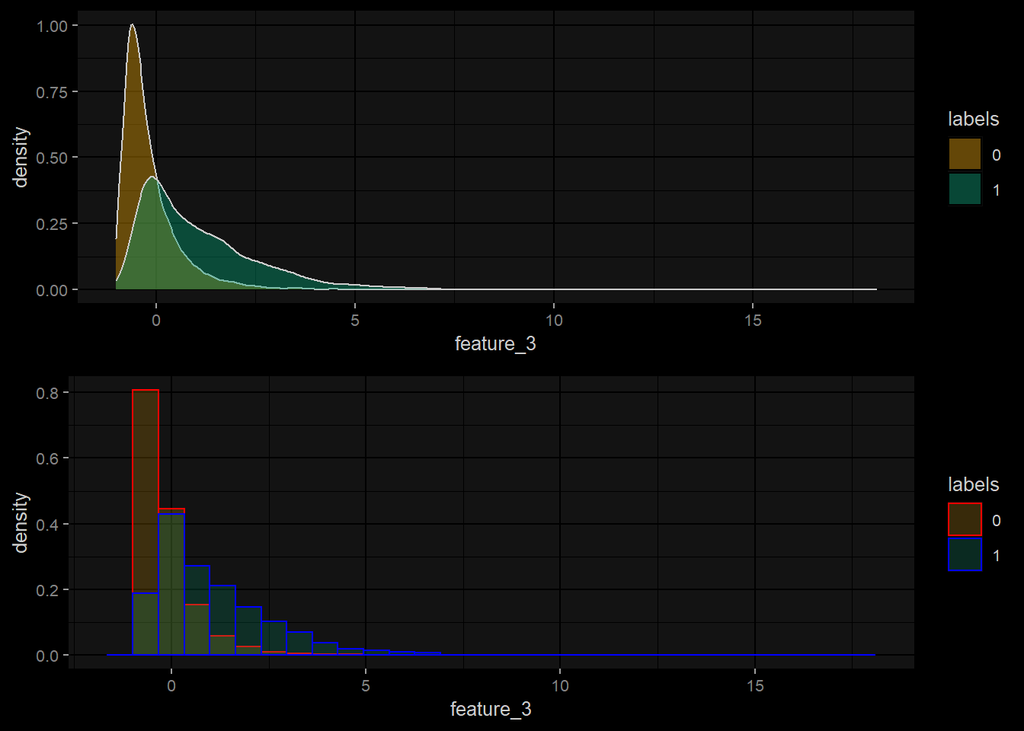

##### Comments:

We can see that the distribution of the feature for different target levels is very promising.It is evident in the density plots as the target levels have some strong separation in certain range.The two different levels have distinct density pattern.As the values are distributed over the range, this feature can be very promising and we need to keep an eye on it in future analysis.

```
## Error : The fig.showtext code chunk option must be TRUE
```

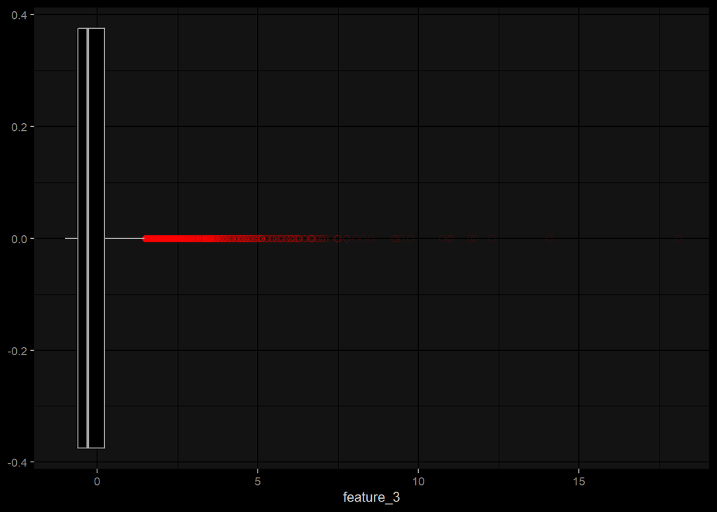

##### Comments:

This is frustrating for this feature that there are plenty of outliers after certain range.I think we can consider a higher cutoff points in regards to the outliers other wise the variable will loose its variability in terms of describing the target variable. We need to be very careful in handling the outliers.

### Feature_4

```
## Error : The fig.showtext code chunk option must be TRUE
```

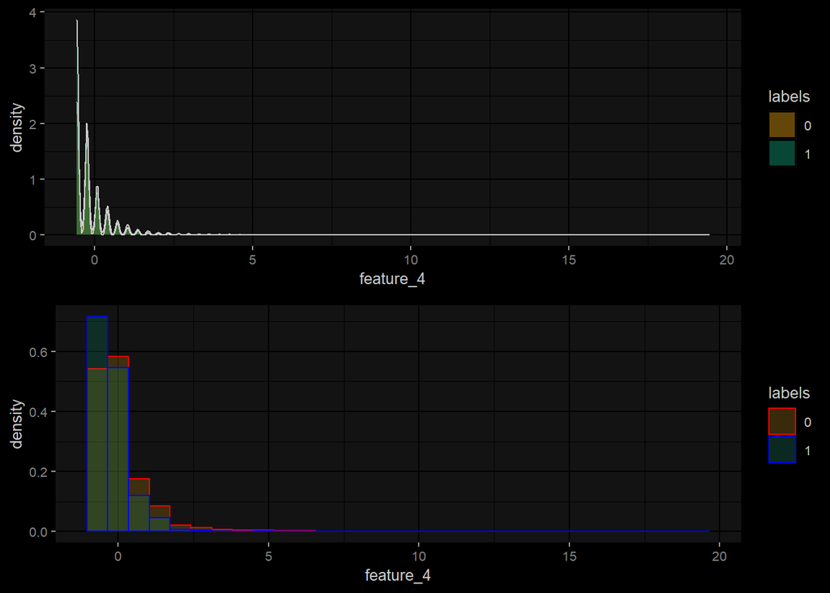

##### Comments:

It seems not so promising in terms of the target level separation but it can be interesting as it has lots of variability within a small range. We definitely need to keep an eye on this variable in future analysis.

```
## Error : The fig.showtext code chunk option must be TRUE
```

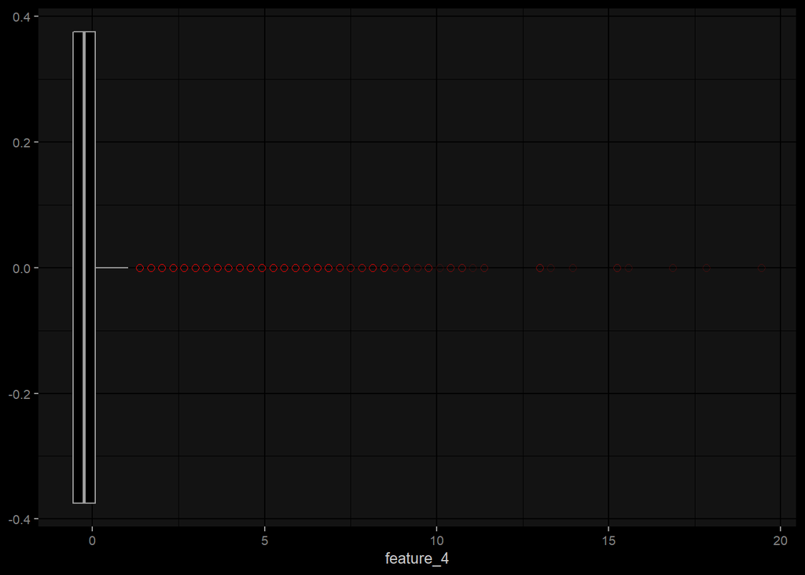

##### Comments:

Few outliers compared to the data size.values seems well distributed over the range.

### Feature_5

```
## Error : The fig.showtext code chunk option must be TRUE
```

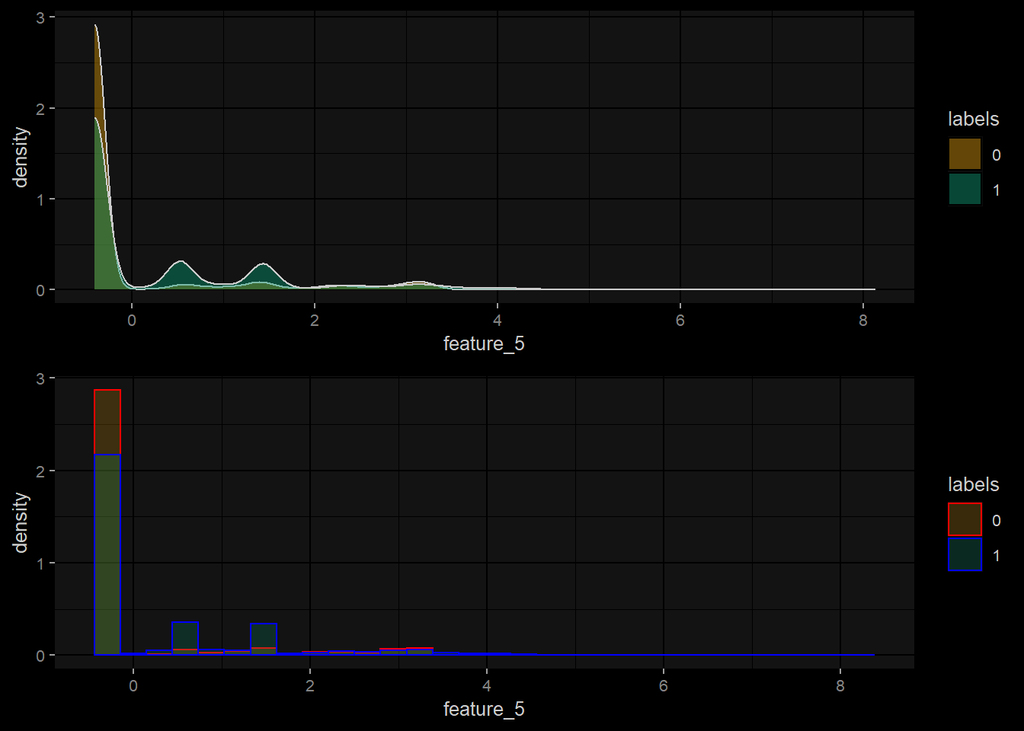

##### Comments:

This variable is also looked promising in terms of variability and separation of different levels in the target variable. We need to confirm the box plot to check its real distribution range for variability.

```
## Error : The fig.showtext code chunk option must be TRUE
```

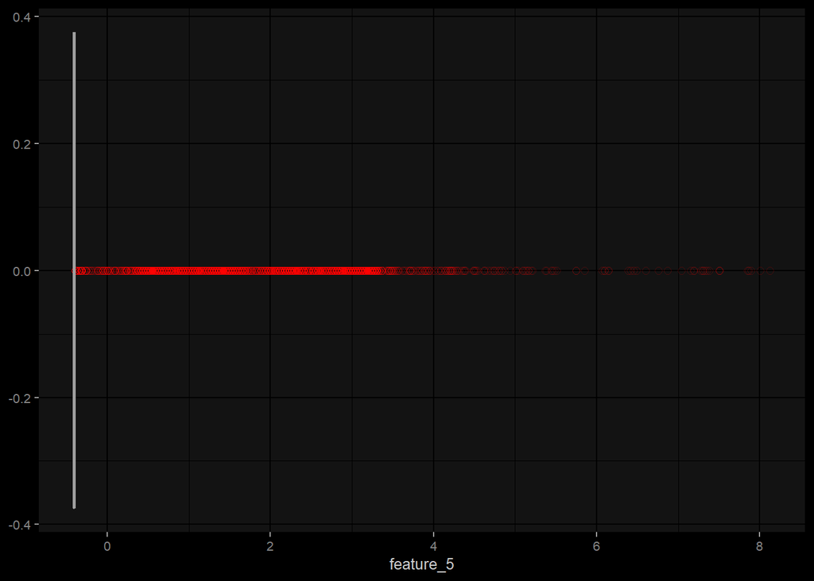

##### Comments:

This is also frustrating for this feature that there are plenty of outliers after certain range.I think we can consider a higher cutoff points as well in regards to the outliers other wise the variable will loose its variability in terms of describing the target variable. The variable is also not distributed well over the range which weakens its ability to explain the target variable

### Feature_6

```
## Error : The fig.showtext code chunk option must be TRUE
```

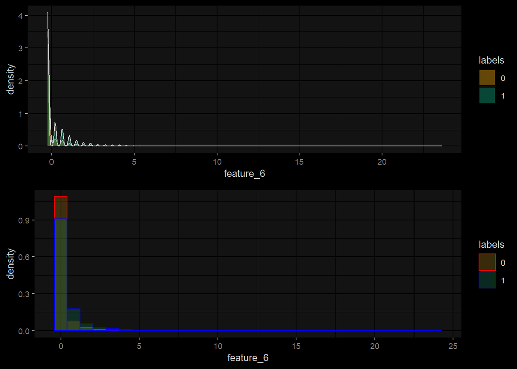

##### Comments:

It seems also not so promising in terms of the target level separation but it can be interesting as it has lots of variability within a small range. We definitely need to keep an eye on this variable in future analysis.

```
## Error : The fig.showtext code chunk option must be TRUE
```

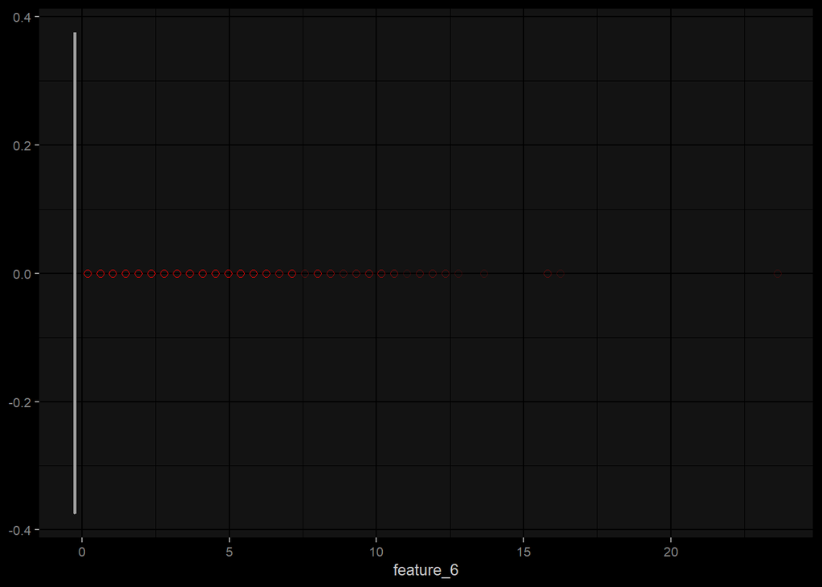

##### Comments:

Although the variable has relatively lower number of outliers but its distribution is extremely concentrated on a particular range which has weaken the ability for this variable to explain the target levels efficiently. It will be interesting to see what the other analysis say about this variable.

##### Comments:

The remaining features are all categorical variables we will perform barplots instead of density/histograms plots to examine the variables.

### Feature_7

```
## Error : The fig.showtext code chunk option must be TRUE
```

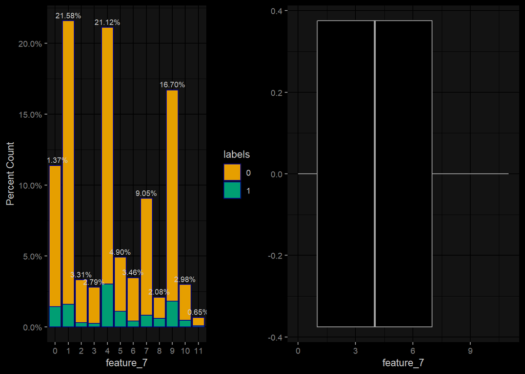

##### Comments:

it is obvious that the data set is imbalance in terms of different levels in the target which we need to confirm when we analyse the target variable itself.Too many levels in this feature and they are not distributed evenly over the target levels.It can make the prediction difficult and biased towards the levels with higher concentration of frequency density.This can be a weak predictor and we need to confirm this in our future analysis.

### feature_8

```
## Error : The fig.showtext code chunk option must be TRUE
```

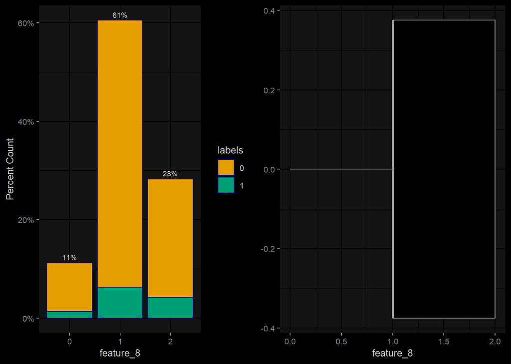

```r
plot1 <- ggplot(df_train, aes(x = as.factor(feature_8))) +
  geom_bar(aes(y = (..count..)/sum(..count..),fill=labels),color="darkblue") +
  geom_text(aes(y = ((..count..)/sum(..count..)), label = scales::percent((..count..)/sum(..count..))), stat = "count", vjust = -0.5,size=2.5) +
  scale_y_continuous(labels = percent) +
  labs( y = "Percent Count", x = "feature_8")

plot2 <- ggplot(data=df_train,aes(x=feature_8))+
    geom_boxplot(outlier.colour = 'red',outlier.size = 2,outlier.alpha = 0.2,outlier.shape = 1)

ggarrange(plot1,plot2,ncol = 2,nrow = 1)
```

##### Comments:

Less number of levels in this feature which is better than the previous predictor.The frequency density is also better but still concentrated on a particular level which can weaken the predictive capability of the target variable for this variable. The distribution of the target variable is also proportionate among the levels which is a good indicator but we need to keep an eye on this variable.

### feature_9

```
## Error : The fig.showtext code chunk option must be TRUE
```

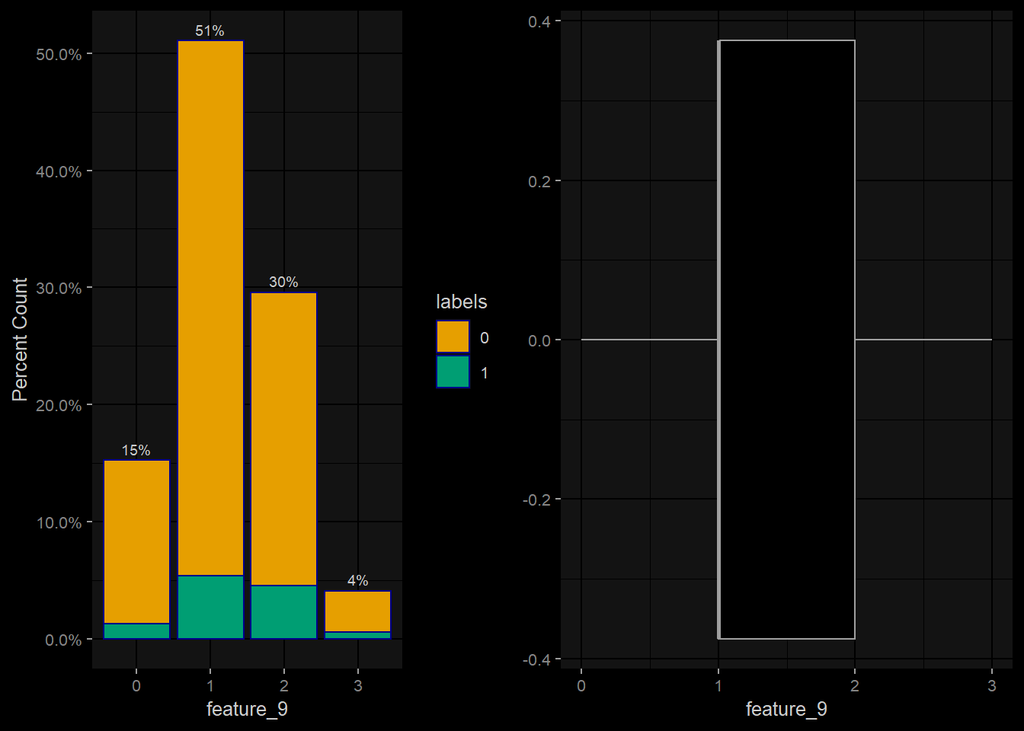

```r
plot1 <- ggplot(df_train, aes(x = as.factor(feature_9))) +
  geom_bar(aes(y = (..count..)/sum(..count..),fill=labels),color="darkblue") +
  geom_text(aes(y = ((..count..)/sum(..count..)), label = scales::percent((..count..)/sum(..count..))), stat = "count", vjust = -0.5,size=2.5) +
  scale_y_continuous(labels = percent) +
  labs( y = "Percent Count", x = "feature_9")

plot2 <- ggplot(data=df_train,aes(x=feature_9))+
    geom_boxplot(outlier.colour = 'red',outlier.size = 2,outlier.alpha = 0.2,outlier.shape = 1)

ggarrange(plot1,plot2,ncol = 2,nrow = 1)
```

##### Comments:

More number of levels in this feature than the previous predictor.The frequency density is also better but still concentrated on particular levels which can weaken the predictive capability of the target variable for this variable. The distribution of the target variable is also proportionate among the levels which is a good indicator. We need to keep an eye on this variable.

### feature_10

```
## Error : The fig.showtext code chunk option must be TRUE
```

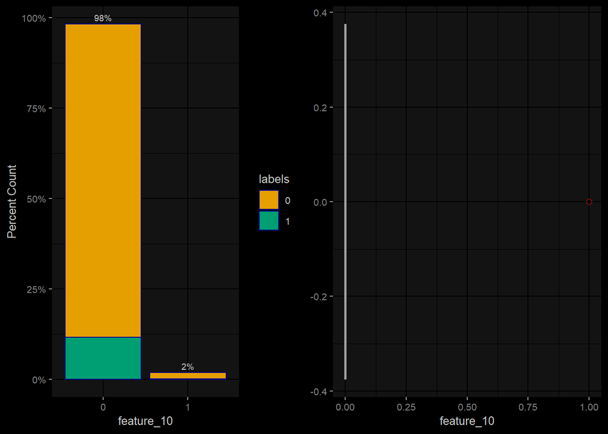

```r
plot1 <- ggplot(df_train, aes(x = as.factor(feature_10))) +
  geom_bar(aes(y = (..count..)/sum(..count..),fill=labels),color="darkblue") +
  geom_text(aes(y = ((..count..)/sum(..count..)), label = scales::percent((..count..)/sum(..count..))), stat = "count", vjust = -0.5,size=2.5) +
  scale_y_continuous(labels = percent) +
  labs( y = "Percent Count", x = "feature_10")

plot2 <- ggplot(data=df_train,aes(x=feature_10))+
    geom_boxplot(outlier.colour = 'red',outlier.size = 2,outlier.alpha = 0.2,outlier.shape = 1)

ggarrange(plot1,plot2,ncol = 2,nrow = 1)
```

##### Comments:

It seems one of the worst predictor in the data set. Only two levels and they are highly imbalanced.more than 85% of the time this predictor can predict the target level 0 even without any analysis or blind foldedly which is better than any machine learning model predictions.This makes this predictor redundant or value-less. We need to confirm this during our other statistical analysis.

### feature_11

```
## Error : The fig.showtext code chunk option must be TRUE
```

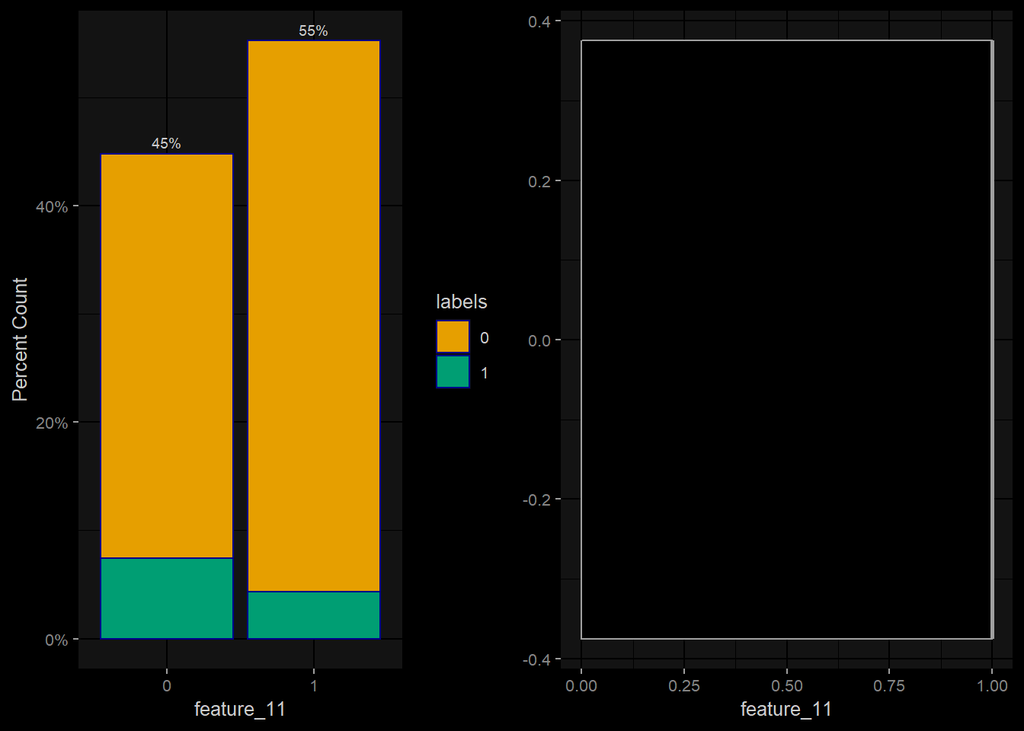

```r
plot1 <- ggplot(df_train, aes(x = as.factor(feature_11))) +
  geom_bar(aes(y = (..count..)/sum(..count..),fill=labels),color="darkblue") +
  geom_text(aes(y = ((..count..)/sum(..count..)), label = scales::percent((..count..)/sum(..count..))), stat = "count", vjust = -0.5,size=2.5) +
  scale_y_continuous(labels = percent) +
  labs( y = "Percent Count", x = "feature_11")

plot2 <- ggplot(data=df_train,aes(x=feature_11))+
    geom_boxplot(outlier.colour = 'red',outlier.size = 2,outlier.alpha = 0.2,outlier.shape = 1)

ggarrange(plot1,plot2,ncol = 2,nrow = 1)
```

##### Comments:

On the contrary to the last predictor , this predictor seems very promising.Less number of levels meaning less chance for confusion, The levels are well and proportionately distributed among the target levels.We need to keep an eye on this variable as this can be one of the best predictor in our data set.

### feature_12

```
## Error : The fig.showtext code chunk option must be TRUE
```

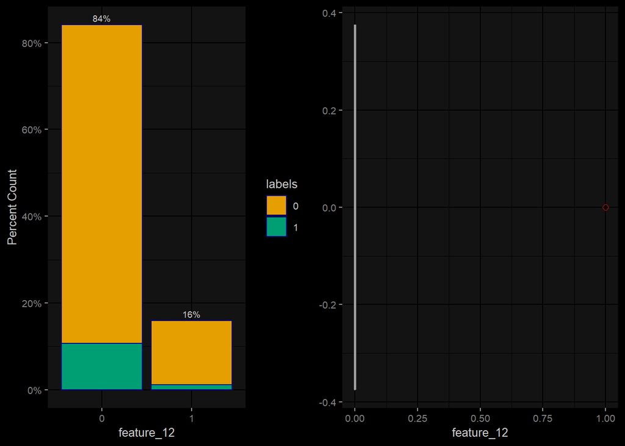

```r
plot1 <- ggplot(df_train, aes(x = as.factor(feature_12))) +
  geom_bar(aes(y = (..count..)/sum(..count..),fill=labels),color="darkblue") +
  geom_text(aes(y = ((..count..)/sum(..count..)), label = scales::percent((..count..)/sum(..count..))), stat = "count", vjust = -0.5,size=2.5) +
  scale_y_continuous(labels = percent) +
  labs( y = "Percent Count", x = "feature_12")

plot2 <- ggplot(data=df_train,aes(x=feature_12))+
    geom_boxplot(outlier.colour = 'red',outlier.size = 2,outlier.alpha = 0.2,outlier.shape = 1)

ggarrange(plot1,plot2,ncol = 2,nrow = 1)
```

##### Comments:

This also seems a good predictor having only two levels. But relatively more imbalance than the last one among the levels but seems proportionally distributed among the target levels.It can be a moderately good predictor.We need to check in our future analysis.

### feature_13

```
## Error : The fig.showtext code chunk option must be TRUE
```

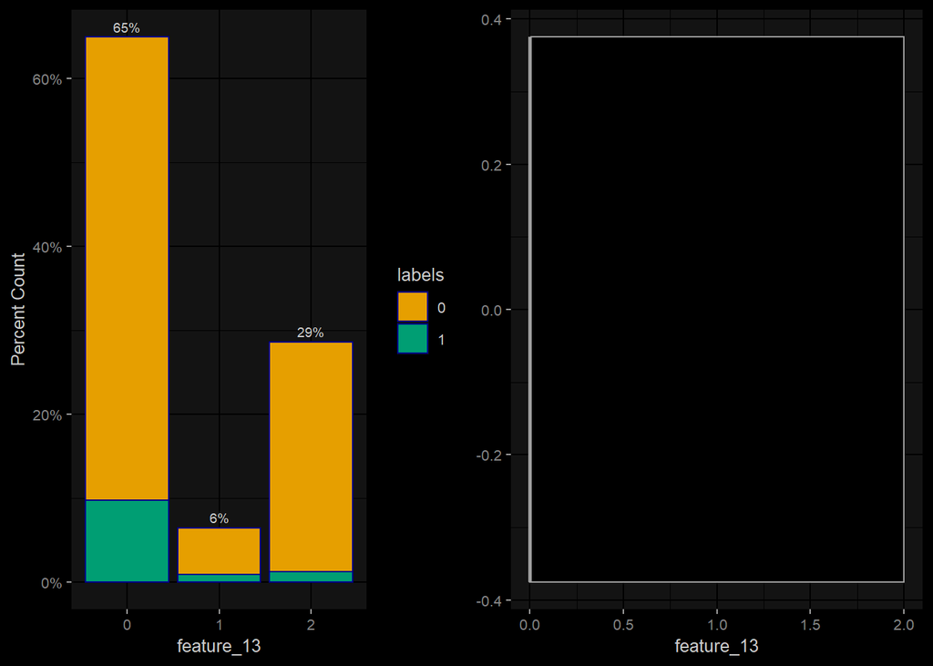

```r
plot1 <- ggplot(df_train, aes(x = as.factor(feature_13))) +
  geom_bar(aes(y = (..count..)/sum(..count..),fill=labels),color="darkblue") +
  geom_text(aes(y = ((..count..)/sum(..count..)), label = scales::percent((..count..)/sum(..count..))), stat = "count", vjust = -0.5,size=2.5) +
  scale_y_continuous(labels = percent) +
  labs( y = "Percent Count", x = "feature_13")

plot2 <- ggplot(data=df_train,aes(x=feature_13))+
    geom_boxplot(outlier.colour = 'red',outlier.size = 2,outlier.alpha = 0.2,outlier.shape = 1)

ggarrange(plot1,plot2,ncol = 2,nrow = 1)
```

##### Comments:

This has more levels than the last one.The distribution of the target levels are not also proportional.if our primary concern is to find the accuracy to get the churn rate high, this predictor can lead to very bad performance in the model.We need to check this variable in our future analysis.

### feature_14

```
## Error : The fig.showtext code chunk option must be TRUE
```

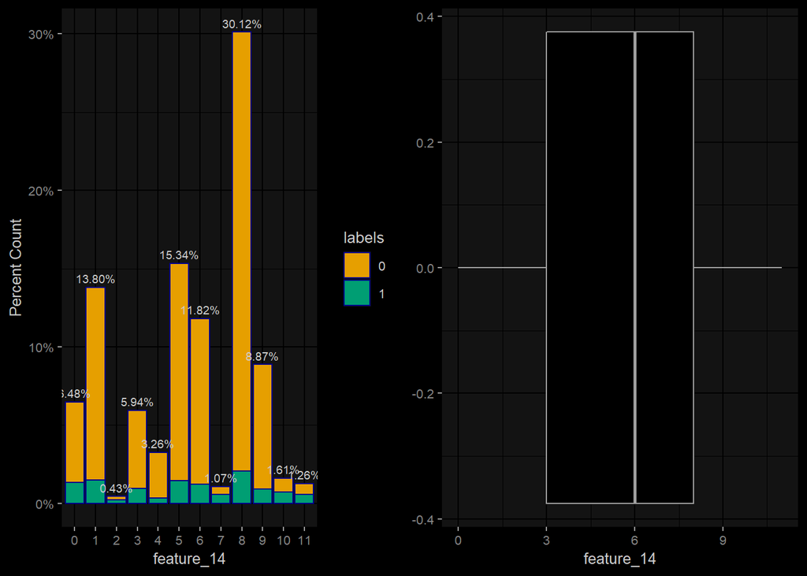

```r
plot1 <- ggplot(df_train, aes(x = as.factor(feature_14))) +
  geom_bar(aes(y = (..count..)/sum(..count..),fill=labels),color="darkblue") +
  geom_text(aes(y = ((..count..)/sum(..count..)), label = scales::percent((..count..)/sum(..count..))), stat = "count", vjust = -0.5,size=2.5) +
  scale_y_continuous(labels = percent) +
  labs( y = "Percent Count", x = "feature_14")

plot2 <- ggplot(data=df_train,aes(x=feature_14))+
    geom_boxplot(outlier.colour = 'red',outlier.size = 2,outlier.alpha = 0.2,outlier.shape = 1)

ggarrange(plot1,plot2,ncol = 2,nrow = 1)
```

##### Comments:

Too many levels and quite biased towards one particular level of the target variable.This can lead to poor performance in case predicting the churn level.We can re-distribute the target levels and see how they perform but still this feature should remain less important features in our data set.

### feature_15

```
## Error : The fig.showtext code chunk option must be TRUE
```

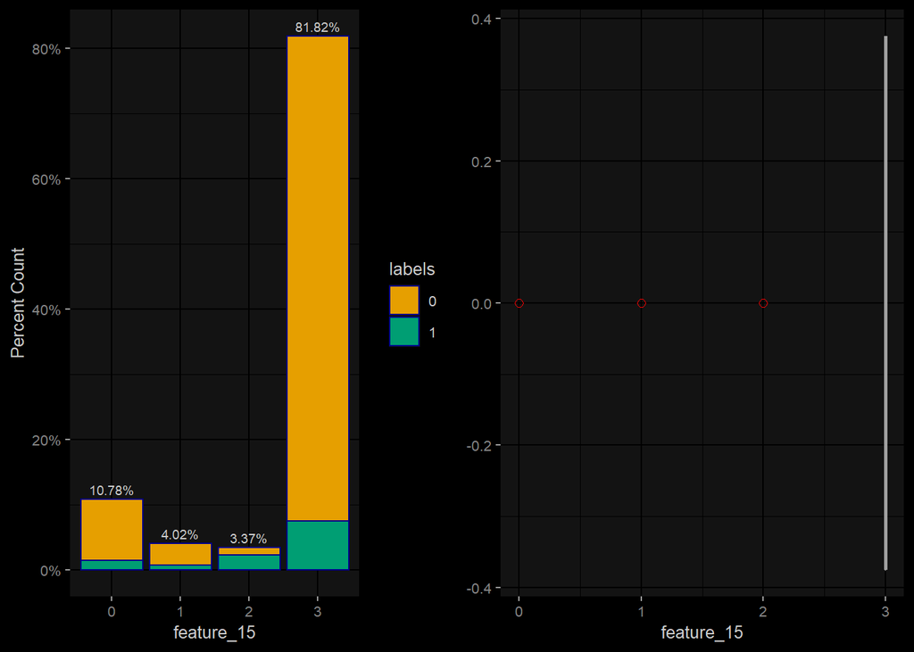

```r
plot1 <- ggplot(df_train, aes(x = as.factor(feature_15))) +
  geom_bar(aes(y = (..count..)/sum(..count..),fill=labels),color="darkblue") +
  geom_text(aes(y = ((..count..)/sum(..count..)), label = scales::percent((..count..)/sum(..count..))), stat = "count", vjust = -0.5,size=2.5) +
  scale_y_continuous(labels = percent) +
  labs( y = "Percent Count", x = "feature_15")

plot2 <- ggplot(data=df_train,aes(x=feature_15))+
    geom_boxplot(outlier.colour = 'red',outlier.size = 2,outlier.alpha = 0.2,outlier.shape = 1)

ggarrange(plot1,plot2,ncol = 2,nrow = 1)
```

##### Comments:

Less number of levels than the last one and the distribution is also better but it concentrate in one level more than others which makes it a relatively weak predictor.We can check the distribution again after balancing the data set along the two target levels.

### Distribution of Target variable

```
## Error : The fig.showtext code chunk option must be TRUE
```

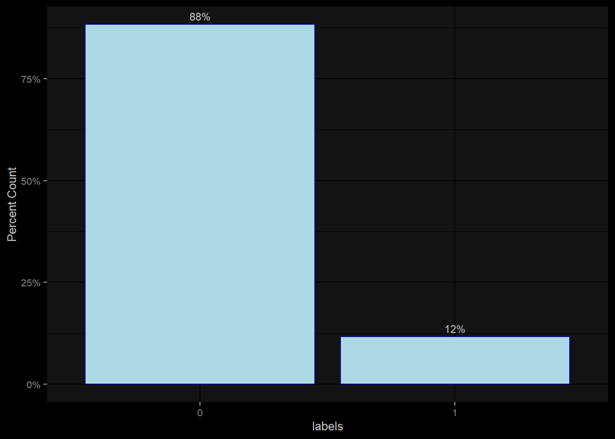

##### Comments:

This is the distribution of our target variable and as suspected the variable is highly imbalanced along its two levels.We will get a 88% accuracy in predicting the target level 0 even without applying any machine learning model.In order to mitigate the problem we need to apply different balancing techniques to make the data set balanced along its different target levels.After balancing what ever performance we will get would be more robust among the levels and would be more reliable.

# Bi-variate analysis

We will load the data set again for Bi-variate analysis only, as correlation and other matrix only work with numerical data.

```r
df_train_cor <- read.csv("trainSet.csv")
```

### Some motivations

We have already performed the uni-variate analysis.Now we want to perform a Bi-variate analysis to see how our predictor variables are correlated with the target variables.We would like to select only those variables which can explain our target variable well or at least in a reasonable margin.On the other hand we need to identify any unnecessary variables which are highly correlated among them selves.The strategy would be if the variables have not enough explaining power for the target variable we would discard both the variables but if they have explaining power we would only keep the stronger one because the other will be redundant and reduce the performance of our predictive models.

In order to find out how the variables are correlated among each other, first we will generate a correlation matrix which can provide us with useful information. Later,for better visualization we would generate a corr-plot to figure out potential variables.Once identified we will only investigate the promising variables as our data set has 17 features and investigating all possible pair of features would be time consuming and unnecessary.

We also know that visualizing continuous variables in a scatter plots is more intuitive than continuous and discrete variables combination.So while performing the pair-plots we will only visualize the continuous pairs and keep track theoretically any other combination.

### Correlation Matrix

```r
cor(df_train_cor)
```

```
##                feature_0    feature_1    feature_2     feature_3     feature_4
## feature_0   1.0000000000  0.104664489 -0.006394331 -0.0077942152  3.282785e-03
## feature_1   0.1046644886  1.000000000  0.004925509  0.0159309983 -1.605165e-02
## feature_2  -0.0063943314  0.004925509  1.000000000 -0.0272739232  1.668426e-01
## feature_3  -0.0077942152  0.015930998 -0.027273923  1.0000000000 -8.397753e-02
## feature_4   0.0032827854 -0.016051652  0.166842601 -0.0839775250  1.000000e+00
## feature_5  -0.0234874440  0.006690639 -0.092230514  0.0028345345 -9.209223e-02
## feature_6  -0.0009054094  0.025959507 -0.051965135 -0.0001471314 -4.662094e-02
## feature_7  -0.0261791189  0.020214825  0.019270918 -0.0000475078  6.772282e-03
## feature_8  -0.4047685279 -0.004822458 -0.008307429  0.0045224276 -6.363128e-03
## feature_9  -0.1070267823  0.061650020  0.022553594  0.0039457533  9.740898e-03
## feature_10 -0.0176269692 -0.067716806  0.010602744 -0.0119563385  1.998700e-02
## feature_11 -0.1820089686 -0.075110830 -0.028254532  0.0064652531 -2.144618e-02
## feature_12 -0.0141880235 -0.085623686  0.008734310 -0.0029186339  6.274744e-05
## feature_13  0.0292657555 -0.029716880 -0.029644979 -0.0217662459  2.765790e-02
## feature_14 -0.0411087361  0.011324668 -0.002747906  0.0082849119 -1.102530e-01
## feature_15  0.0067136973 -0.025227902  0.080137983  0.0094848089  1.057264e-01
## labels      0.0155022867  0.050640846 -0.029756113  0.3900897354 -7.615220e-02
##               feature_5     feature_6     feature_7    feature_8    feature_9
## feature_0  -0.023487444 -0.0009054094 -0.0261791189 -0.404768528 -0.107026782
## feature_1   0.006690639  0.0259595074  0.0202148254 -0.004822458  0.061650020
## feature_2  -0.092230514 -0.0519651346  0.0192709183 -0.008307429  0.022553594
## feature_3   0.002834535 -0.0001471314 -0.0000475078  0.004522428  0.003945753
## feature_4  -0.092092230 -0.0466209403  0.0067722823 -0.006363128  0.009740898
## feature_5   1.000000000  0.5474004184 -0.0177196502  0.017800728  0.003091045
## feature_6   0.547400418  1.0000000000  0.0052729415  0.022389006  0.021375909
## feature_7  -0.017719650  0.0052729415  1.0000000000  0.062570846  0.166103586
## feature_8   0.017800728  0.0223890062  0.0625708456  1.000000000  0.110684649
## feature_9   0.003091045  0.0213759094  0.1661035864  0.110684649  1.000000000
## feature_10 -0.034743896 -0.0220792359 -0.0069793409 -0.004834902 -0.011660351
## feature_11  0.122213685  0.0353729863 -0.1282364908 -0.018921527 -0.091514170
## feature_12 -0.024377163 -0.0129390427 -0.0346910562 -0.051098764 -0.045978083
## feature_13 -0.243558736 -0.1795058575 -0.0832531355 -0.035602747 -0.113467396
## feature_14  0.032152793  0.0275546351 -0.0903350178 -0.004377471 -0.058873129
## feature_15 -0.855404526 -0.5959617326  0.0075542854 -0.014895982 -0.023284727
## labels      0.110576833  0.1190420249  0.0367109721  0.042540660  0.068838639
##              feature_10   feature_11    feature_12  feature_13   feature_14
## feature_0  -0.017626969 -0.182008969 -1.418802e-02  0.02926576 -0.041108736
## feature_1  -0.067716806 -0.075110830 -8.562369e-02 -0.02971688  0.011324668
## feature_2   0.010602744 -0.028254532  8.734310e-03 -0.02964498 -0.002747906
```

[output cut: 17 more lines]

```
## feature_2   0.080137983 -0.02975611
## feature_3   0.009484809  0.39008974
## feature_4   0.105726429 -0.07615220
## feature_5  -0.855404526  0.11057683
## feature_6  -0.595961733  0.11904202
## feature_7   0.007554285  0.03671097
## feature_8  -0.014895982  0.04254066
## feature_9  -0.023284727  0.06883864
## feature_10  0.037574806 -0.02411465
## feature_11 -0.099500570 -0.13572276
## feature_12  0.016573835 -0.06511450
## feature_13  0.270876882 -0.14820666
## feature_14 -0.034777881 -0.02532398
## feature_15  1.000000000 -0.08062353
## labels     -0.080623528  1.00000000
```

### Correlation Matrix in plots

```
## Error : The fig.showtext code chunk option must be TRUE
```

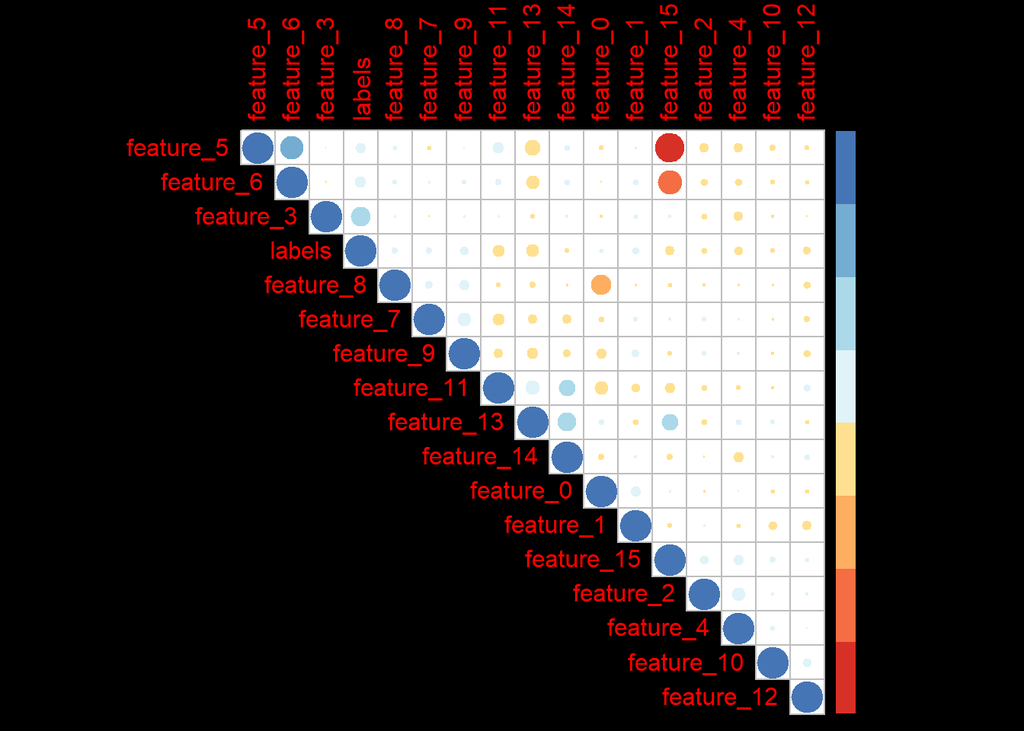

##### Comments:

From the correlation matrix and corr-plot, we can see that among the continuous variables, feature 5 and 6 are correlated among themselves and feature 2 and 4 are also correlated.So there are chances that they become redundant and we need to investigate further.

### Pair of Features that has significant correlations

```
## # Correlation Matrix (auto-method)
##
## Parameter1 | Parameter2 |     r |         95% CI | t(27124) |         p
## -----------------------------------------------------------------------
## feature_0  |  feature_8 | -0.40 | [-0.41, -0.39] |   -72.90 | < .001***
## feature_0  | feature_11 | -0.18 | [-0.19, -0.17] |   -30.48 | < .001***
## feature_2  |  feature_4 |  0.17 | [ 0.16,  0.18] |    27.87 | < .001***
## feature_3  |     labels |  0.39 | [ 0.38,  0.40] |    69.77 | < .001***
## feature_5  |  feature_6 |  0.55 | [ 0.54,  0.56] |   107.73 | < .001***
## feature_5  | feature_13 | -0.24 | [-0.25, -0.23] |   -41.36 | < .001***
## feature_5  | feature_15 | -0.86 | [-0.86, -0.85] |  -271.99 | < .001***
## feature_6  | feature_13 | -0.18 | [-0.19, -0.17] |   -30.05 | < .001***
## feature_6  | feature_15 | -0.60 | [-0.60, -0.59] |  -122.23 | < .001***
## feature_7  |  feature_9 |  0.17 | [ 0.15,  0.18] |    27.74 | < .001***
## feature_10 | feature_12 |  0.28 | [ 0.27,  0.29] |    47.86 | < .001***
## feature_11 | feature_13 |  0.19 | [ 0.18,  0.20] |    31.89 | < .001***
## feature_11 | feature_14 |  0.27 | [ 0.26,  0.28] |    45.97 | < .001***
## feature_11 |     labels | -0.27 | [-0.29, -0.26] |   -46.99 | < .001***
## feature_12 |     labels | -0.18 | [-0.19, -0.17] |   -30.14 | < .001***
## feature_13 | feature_14 |  0.36 | [ 0.35,  0.37] |    63.61 | < .001***
## feature_13 | feature_15 |  0.27 | [ 0.26,  0.28] |    46.34 | < .001***
##
## p-value adjustment method: Holm (1979)
## Observations: 27126
```

##### Comments:

we have performed a correlation test and list out some of the potential pairs which has relatively high correlation(our cut off point was +/- 0.15) among themselves with certain confidence interval.This verifies our initial visual findings about correlations among the pairs.Here we can see that in terms of correlating with the target variable , feature 3, 11, 12 looks promising.

### Some Importatnt relationships from correlation matrix

Pair plots for feature_5 vs feature_6

```
## Error : The fig.showtext code chunk option must be TRUE
```

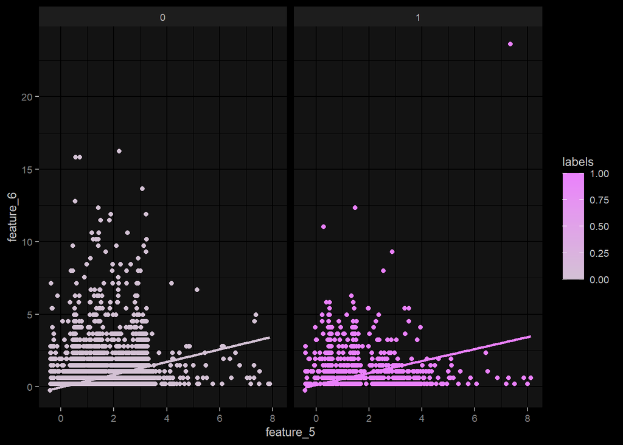

Pair plots for feature_2 vs feature_4

```
## Error : The fig.showtext code chunk option must be TRUE
```

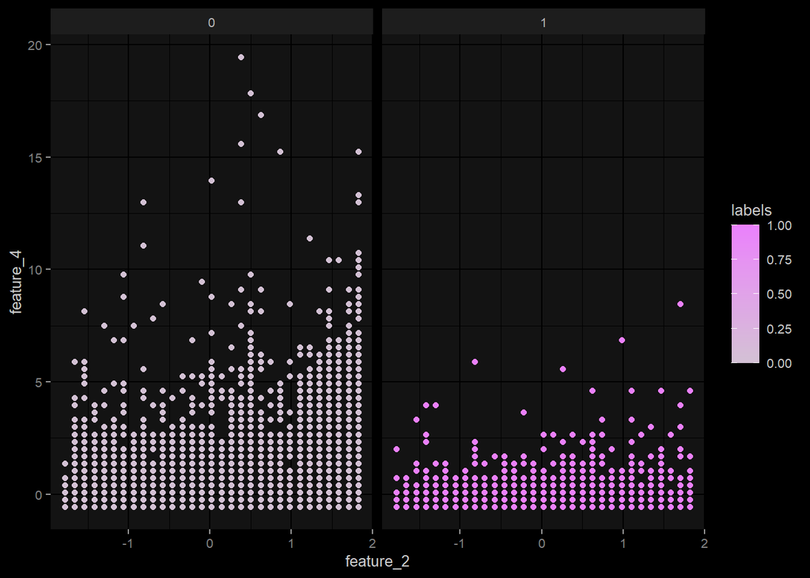

##### Comments:

in above plots, I tried to plot the two suspected pairs which seems are correlated with each other along the different target levels.Before taking any decision about the variables in the pairs i want to perform one last test , which is to calculate the variable importance calculations.On the basis of that finding and other analysis i have already done , i will take my final decision about which variables we should discard and which should be kept.

# Data Partitioning

```r
set.seed(550)
ind <- sample(2,nrow(df_train),replace = TRUE,prob = c(0.8,0.2))
# Split the train data set into train and validate sets with 80/20 ratio
train <- df_train[ind==1,]
validate <- df_train[ind==2,]
```

# Variable Importance

Variable Importance Statistically:

```r
logit <- train(labels~.,data=train,method='glm',preProcess=c('scale','center'))
summary(logit)
```

```
##
## Call:
## NULL
##
## Deviance Residuals:
##     Min       1Q   Median       3Q      Max
## -5.5469  -0.4527  -0.2923  -0.1699   3.1466
##
## Coefficients:
##             Estimate Std. Error z value Pr(>|z|)
## (Intercept) -2.68009    0.03367 -79.592  < 2e-16 ***
## feature_0    0.05873    0.02580   2.277   0.0228 *
## feature_1    0.05065    0.02008   2.522   0.0117 *
## feature_2   -0.04353    0.02480  -1.755   0.0792 .
## feature_3    0.99338    0.02236  44.428  < 2e-16 ***
## feature_4   -0.43255    0.04586  -9.432  < 2e-16 ***
## feature_5    0.38504    0.03603  10.687  < 2e-16 ***
## feature_6    0.19348    0.02147   9.013  < 2e-16 ***
## feature_7    0.03267    0.02525   1.294   0.1957
## feature_8    0.11114    0.02698   4.119 3.81e-05 ***
## feature_9    0.14635    0.02487   5.884 4.02e-09 ***
## feature_10  -0.05292    0.03164  -1.673   0.0944 .
## feature_11  -0.49900    0.02712 -18.402  < 2e-16 ***
## feature_12  -0.26159    0.03012  -8.684  < 2e-16 ***
## feature_13  -0.55499    0.03464 -16.021  < 2e-16 ***
## feature_14   0.10136    0.02410   4.207 2.59e-05 ***
## feature_15   0.26045    0.04150   6.276 3.46e-10 ***
## ---
## Signif. codes:  0 '***' 0.001 '**' 0.01 '*' 0.05 '.' 0.1 ' ' 1
##
## (Dispersion parameter for binomial family taken to be 1)
##
##     Null deviance: 15667  on 21662  degrees of freedom
## Residual deviance: 11687  on 21646  degrees of freedom
## AIC: 11721
##
## Number of Fisher Scoring iterations: 6
```

Comments: Based on the above summary we can conclude that the features 3-6 then 8,9 and 11-15 are most important,feature 0 and 1 are some what and feature 2,7 and 10 are least important in explaining target variable labels.We can discard these variables and still can achieve good outcome in our models .

Variable Importance Graphically:

```
## Error : The fig.showtext code chunk option must be TRUE
```

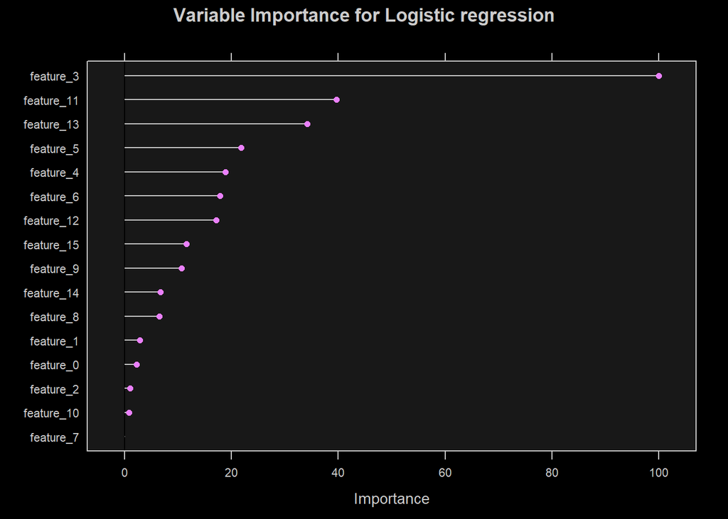

##### Comments:

In addition to that i want to delete variable 6 as well although it is statistically significant but we have already deduced that it is highly correlated with variable 5 and keeping them together would hamper the model performance.

# Model Development

### Motivation

Before developing any model we need to select two models as per the requirement of the assignment.Considering our data set, there are 16 features and 1 target variable.The target variable is categorical and some of the features too , so we can’t use linear regression model.As we have 7 continuous variable and 8 categorical variables, we have choose a model which can work well with both categorical and numeric values.And as the target variable has only 2 separate levels i deiced to use  
1. Binomial Logistic regression and  
2. Random Forest

## Feature selection

##### Comments:

We have deleted all the features that seems least important/significant as well as redundant

## Final Data sets

```r
train_final <- train[,-c(3,8,11,7)]
validate_final <- validate[,-c(3,8,11,7)]
```

## Both over and under sampling

##### Comments:

To reduce the effect of imbalanced data we did sampling with a combination of under and over sampling methods

```
##
##     0     1
## 10095  9905
```

# Target Distribution after Balancing

```
## Error : The fig.showtext code chunk option must be TRUE
```

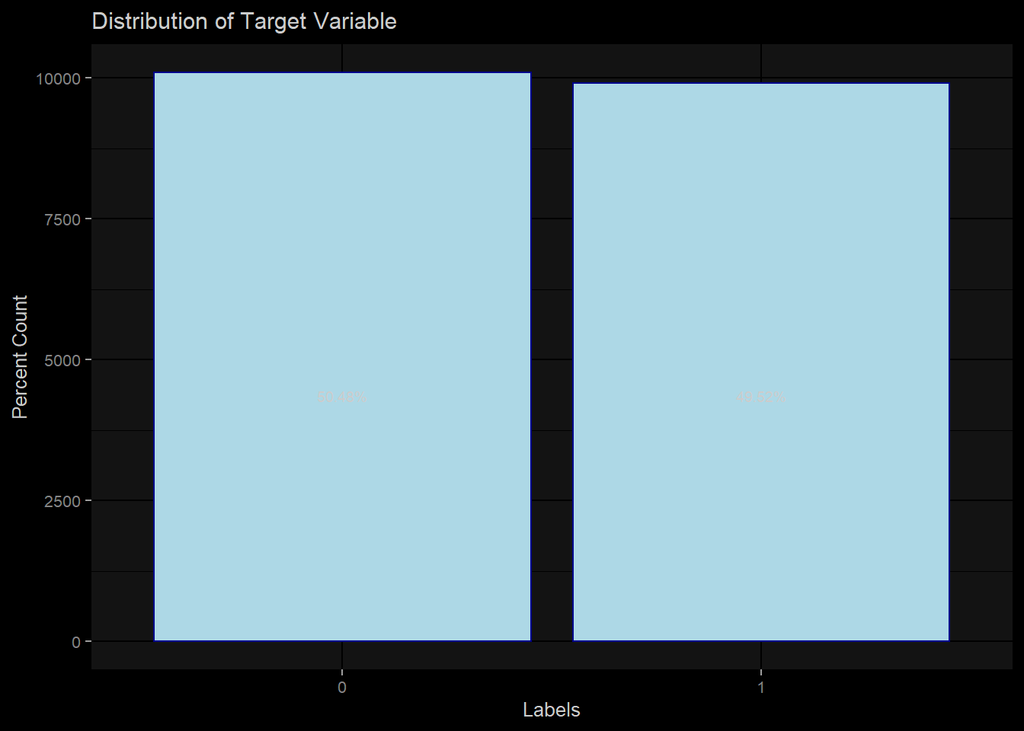

##### Comments:

We can see that the data set is now well balanced along the different target levels.This data set will be suitable for more robust performance in predicting the target variable accross the levels.

# Model Selection

## Random Forests without balancing the Data set

```r
set.seed(555)
rf_without_balancing <- randomForest(labels~.,data=train_final)
cm_without_balancing <- confusionMatrix(predict(rf_without_balancing,validate_final),validate_final$labels,positive='1')
cm_without_balancing
```

```
## Confusion Matrix and Statistics
##
##           Reference
## Prediction    0    1
##          0 4702  386
##          1  121  254
##
##                Accuracy : 0.9072
##                  95% CI : (0.8992, 0.9148)
##     No Information Rate : 0.8828
##     P-Value [Acc > NIR] : 4.397e-09
##
##                   Kappa : 0.4532
##
##  Mcnemar's Test P-Value : < 2.2e-16
##
##             Sensitivity : 0.39687
##             Specificity : 0.97491
##          Pos Pred Value : 0.67733
##          Neg Pred Value : 0.92414
##              Prevalence : 0.11715
##          Detection Rate : 0.04649
##    Detection Prevalence : 0.06864
##       Balanced Accuracy : 0.68589
##
##        'Positive' Class : 1
##
```

## Random Forests with balanced Data set

```r
start1 <- proc.time()
set.seed(555)
rf_with_balancing <- randomForest(labels~.,data=both)
cm_with_balancing <- confusionMatrix(predict(rf_with_balancing,validate_final),validate_final$labels,positive='1')
stop1 <- proc.time()
```

```r
performance[nrow(performance)+1,] = c("w_balancing",cm_with_balancing$overall[[1]],cm_with_balancing$byClass[[1]],cm_with_balancing$byClass[[2]])
```

## Comparing the performances in RF

```
## Error : The fig.showtext code chunk option must be TRUE
```

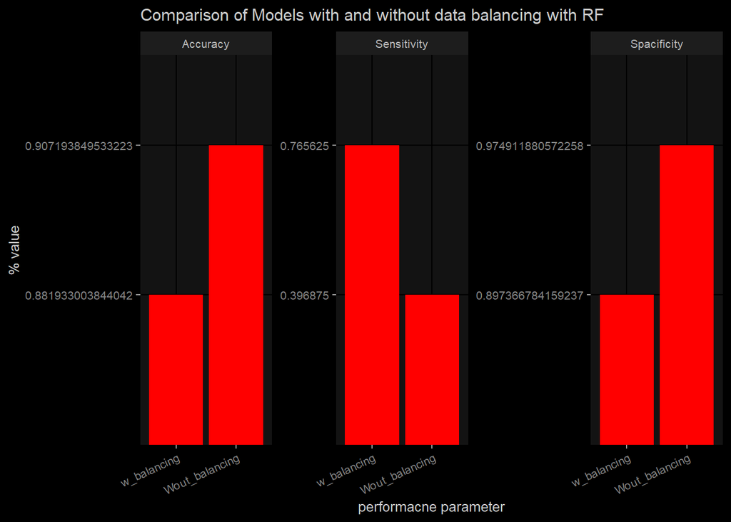

```r
df <- melt(performance,id="Model")
p_rf <- ggplot(df,aes(Model,value))+geom_col(fill='red')+ facet_wrap(~variable, scales = "free_y", ncol = 3)+
   theme(axis.text.x = element_text(angle = 25, vjust = 1, hjust = 1))+labs(x="performacne parameter",y="% value",title="Comparison of Models with and without data balancing with RF")
p_rf
```

##### Comments:

We can observe from the comparison table that Model performance improved significantly accross the target level after the data has been balanced on both levels.The accuracy was very high before the data set was balanced.This is due to the fact the the target level which has higher frequency, played a major role in this accuracy.But target level with low frequency can suffer due to little learning during training phases.Thats why when we check sensitivity which determines how accurately it can predict churn rate , the model performed very poor. But when we balanced the dataset , the model got sufficient opportunity to learn from situations when the customer churns and performed way better.In this process we loose some capacity to identify the other level like when the customer will not churn but that is acceptable as by loosing a little we can improve a lot at our desired target level.

So we understand that we can improve the performance of the model based on the Business goal of the organization and in our case as the business goal was to predict customers with possibility to churn, i think my motivation to balance the data set is proved correct.

## Logistic Regression without balancing the Data set

```
## Confusion Matrix and Statistics
##
##           Reference
## Prediction    0    1
##          0 4735  510
##          1   88  130
##
##                Accuracy : 0.8905
##                  95% CI : (0.882, 0.8987)
##     No Information Rate : 0.8828
##     P-Value [Acc > NIR] : 0.03944
##
##                   Kappa : 0.2589
##
##  Mcnemar's Test P-Value : < 2e-16
##
##             Sensitivity : 0.2031
##             Specificity : 0.9818
##          Pos Pred Value : 0.5963
##          Neg Pred Value : 0.9028
##              Prevalence : 0.1172
##          Detection Rate : 0.0238
##    Detection Prevalence : 0.0399
##       Balanced Accuracy : 0.5924
##
##        'Positive' Class : 1
##
```

## Logistic Regression with balancing the Data set

```
## Confusion Matrix and Statistics
##
##           Reference
## Prediction    0    1
##          0 3910  138
##          1  913  502
##
##                Accuracy : 0.8076
##                  95% CI : (0.7969, 0.818)
##     No Information Rate : 0.8828
##     P-Value [Acc > NIR] : 1
##
##                   Kappa : 0.3902
##
##  Mcnemar's Test P-Value : <2e-16
##
##             Sensitivity : 0.78438
##             Specificity : 0.81070
##          Pos Pred Value : 0.35477
##          Neg Pred Value : 0.96591
##              Prevalence : 0.11715
##          Detection Rate : 0.09189
##    Detection Prevalence : 0.25902
##       Balanced Accuracy : 0.79754
##
##        'Positive' Class : 1
##
```